# DAY 10: Project Development & Reporting

R for Professionals – Short Course

2025-09-21

# DAY 10: Project Development & Reporting

**Theme:** Capstone Project & Professional Presentation

## Morning Session (2 hours)

### Learning Objectives

By the end of this session, participants will be able to: - Create professional R Markdown reports  
- Automate reproducible analyses  
- Plan and structure a data project  
- Apply data storytelling and best practices in business communication

### 1. Introduction to R Markdown for Professional Reports

R Markdown combines **narrative, code, and output** into a single document.  
Benefits:  
- Reproducible: Same code + same data = same results  
- Dynamic: Updates automatically with new data  
- Professional: Publication-quality reports  
- Versatile: HTML, PDF, or Word outputs

#### Example: Load Packages and Dataset

```r
# Load essential packages
library(tidyverse)
```

```r
library(ggplot2)
library(knitr)
# Use built-in dataset for demonstration
data("mtcars")
head(mtcars)
```

```
##                    mpg cyl disp  hp drat    wt  qsec vs am gear carb
## Mazda RX4         21.0   6  160 110 3.90 2.620 16.46  0  1    4    4
## Mazda RX4 Wag     21.0   6  160 110 3.90 2.875 17.02  0  1    4    4
## Datsun 710        22.8   4  108  93 3.85 2.320 18.61  1  1    4    1
## Hornet 4 Drive    21.4   6  258 110 3.08 3.215 19.44  1  0    3    1
## Hornet Sportabout 18.7   8  360 175 3.15 3.440 17.02  0  0    3    2
## Valiant           18.1   6  225 105 2.76 3.460 20.22  1  0    3    1
```

#### Quick Plot Example

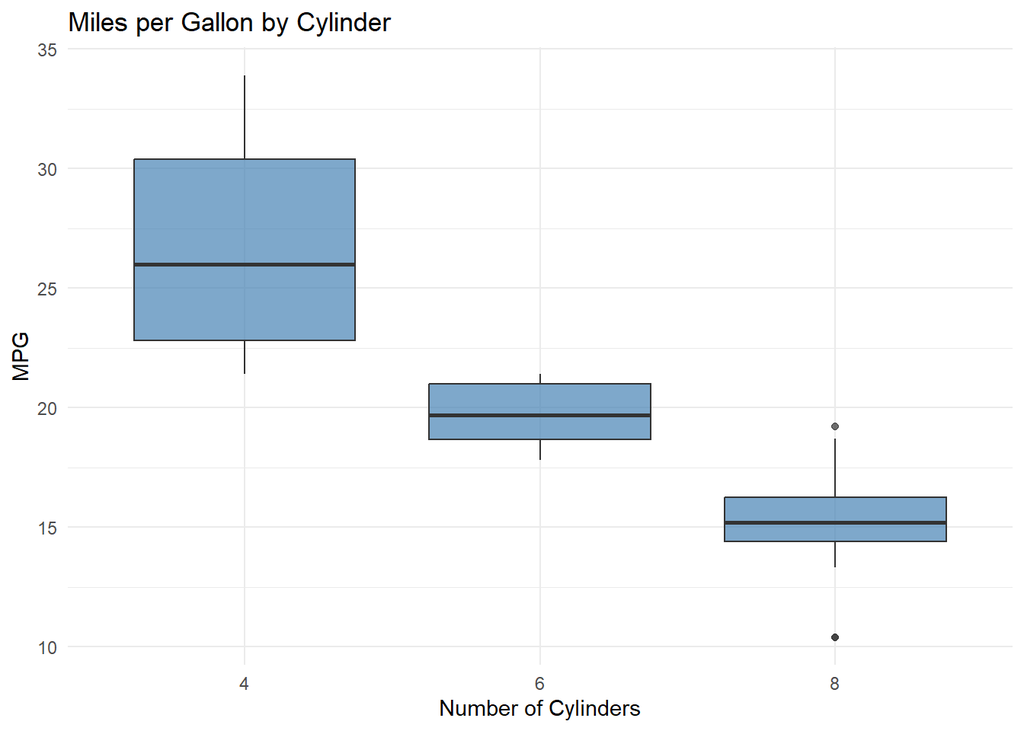

```r
ggplot(mtcars, aes(x = factor(cyl), y = mpg)) +
  geom_boxplot(fill = "steelblue", alpha = 0.7) +
  labs(
    title = "Miles per Gallon by Cylinder",
    x = "Number of Cylinders",
    y = "MPG"
  ) +
  theme_minimal()
```

### 2. Creating Automated, Reproducible Analyses

Dynamic content updates automatically as data changes.

```r
# Compute total and average MPG
total_mpg <- sum(mtcars$mpg)
avg_mpg <- mean(mtcars$mpg)

# Insert dynamically in text
paste0("Total MPG across all cars: ", round(total_mpg,1),
       "; Average MPG: ", round(avg_mpg,1))
```

```
## [1] "Total MPG across all cars: 642.9; Average MPG: 20.1"
```

#### Conditional Content Example

```r
if(avg_mpg > 20){
  avg_text <- "Average MPG is above 20 – efficient fleet"
} else {
  avg_text <- "Average MPG is below 20 – consider efficiency measures"
}
avg_text
```

```
## [1] "Average MPG is above 20 – efficient fleet"
```

### 3. Project Planning and Data Storytelling

Use the **STAR framework** to communicate your results effectively:  
- **Situation:** Context of the analysis  
- **Task:** What needed to be done  
- **Action:** Steps and analysis performed  
- **Result:** Key findings and recommendations

#### Example: Data Aggregation with dplyr

```r
# Average MPG by cylinder group
mtcars %>%
  group_by(cyl) %>%
  summarise(avg_mpg = mean(mpg)) %>%
  knitr::kable(caption = "Average MPG by Cylinder Group")
```

Average MPG by Cylinder Group

| cyl | avg_mpg |
| --- | --- |
| 4 | 26.66364 |
| 6 | 19.74286 |
| 8 | 15.10000 |

### 4. Best Practices for Business Communication

- Focus on **insights and implications**, not just numbers
- Include **charts that tell a story**
- Keep code **organized and documented**
- Use **dynamic text and tables** for automation

## Afternoon Session (2 hours)

### Capstone Project Presentations

Each participant presents a **10-minute analysis** of:  
- **Work-related dataset** OR  
- **Provided business case study**

**Presentation Structure:** 1. Introduction (1 min): Business problem & data scope  
2. Data Overview (2 min): Dataset characteristics & key variables  
3. Analysis & Findings (5 min): Main visuals & insights  
4. Recommendations (2 min): Actionable next steps

### Example Capstone Project: Customer Churn Analysis

```r
# Load your dataset
# customer_data <- read_csv("customer_data.csv")

# Summarize key variables
# summary(customer_data)

# Visualize churn by category
# ggplot(customer_data, aes(x = age_group, y = churned)) +
#   geom_bar(stat="identity", fill="coral") +
#   labs(title="Customer Churn by Age Group", x="Age Group", y="Churned")
```

### Peer Feedback and Discussion

- Provide constructive feedback on **business focus, visualizations, and recommendations**
- Discuss insights and **best practices**
- Encourage **collaboration and learning from peers**

## Key Activities & Checklist

- Complete end-to-end data analysis project
- Create professional R Markdown report
- Include dynamic calculations and visualizations
- Present findings to the group
- Receive completion certificate

## Final Deliverable

- **Professional report** with:
  - Problem statement
  - Data exploration and quality assessment
  - Analytical results & clear visualizations
  - Actionable business recommendations

## Notes for Participants

- Focus on **reproducibility**
- Use **STAR framework** for presenting results
- Ensure plots and tables **support insights**
- Document code clearly for **peer review**

## Next Steps

- Apply R skills to **current work projects**
- Continue practicing with **new datasets**
- Share insights with **colleagues and peers**
- Join **R user communities** for ongoing support

# 🎓 Congratulations!

You have completed **Day 10** and are ready to deliver professional, reproducible data analyses and presentations.